## Week 1 Drill

### Problem 1

Here is an excerpt from the baby-name data in `"DCF::BabyNames"`.

| name | sex | count | year |
| --- | --- | --- | --- |
| Taffy | F | 19 | 1970 |
| Liliana | F | 162 | 1973 |
| Stan | M | 55 | 1975 |
| Nettie | F | 45 | 1978 |
| Kateria | F | 8 | 1980 |
| Nataki | F | 5 | 1982 |
| Danyell | M | 13 | 1984 |
| Ahmet | M | 6 | 1986 |

For each of the following, say whether the variable is quantitative or categorical:

- `Taffy`:
- `year`:
- `sex`:
- `name`:
- `count`:

### Problem 2

Newcomers often get confused about the difference between a quoted character string and an object name. You’re going to explore the difference using the `View()` function. `View()` lets you see the contents of objects.

1. Look briefly at the documentation, via the `help()` function, for the data table `msleep` (in the `ggplot2` package).
2. Look at the data table itself: `View( msleep )`
3. Now do the same thing, but using the quoted character string `"msleep"` rather than the name of the object. That is, `View( “msleep” ).

In your own words, briefly explain the difference between `msleep` and `"msleep"`.

### Problem 3

Bring into your R session the data table named `WorldCities` from the `DCF` package. Use `View( WorldCities )` to look at the data.

- How many cases are there?
- What are the variables?
- Using the documentation provided by `help()`, say what the `date` variable means.

### Problem 4

There are several small, example data tables in the `ggplot2` package. Look at the `msleep` data table by using the `View()` function with the name of the object as an argument.

- What is the meaning of the `brainwt` variable?
- How many cases are there?
- What is the real-world meaning of a case?
- What are the levels of the `vore` variable?

### Problem 5

There are several small, example data tables in the `datasets` package. Look at the `Seatbelts` data table using the `View()` function and the name of the object as an argument.

- What is the meaning of the `front` variable?
- How many cases are there?
- What is the real-world meaning of a case?
- How many letters are there in a typical entry for `country`?

### Problem 6

Say what content is associated each of the following filename extensions.

`.csv`

`.Rmd`

`.jpg`

`.Rdata`

`.docx`

`.html`

`.ppt`

`.png`

`.txt`

`.xls`

### Problem 7

What is the path name of the files in this directory?

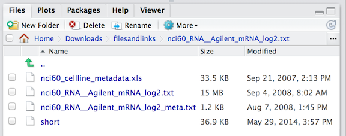

### Problem 8

Which characters can be used in an object name?

### Problem 9

Here are a few characters: . , ; _ - ^ [space] ( )

- Which of those characters can be used in the name of an R object?
- Which of those characters can be used in a quoted character string?

### Problem 10

The `date()` function returns an indication of the current time and date.

- What arguments does `date()` take? How did you find out?
- What *kind* of object is the result from `date()`.

### Problem 11

For each of the following assignment statements, say what is the mistake.

- `ralph <- sqrt 10`
- `ralph2 <-- "Hello to you!"`
- `3ralph <- "Hello to you!"`
- `ralph4 <- "Hello to you!`
- `ralph5 <- date()`

### Problem 12

These questions should be easy to answer if you use the appropriate commands to load, view, or get documentation on the datasets.

- How many variables are there in `CountryData`?
- What does the variable `tfat` measure in the `NHANES` data table?
- How many cases are there in `WorldCities`?
- What’s the third variable in `BabyNames`?
- What are the codes for the levels of the categorical variable `party` in the `registeredVoters` data table, and what does each code stand for?

Please use the comment system to make suggestions, point out errors, or to discuss the topic.